# Univaf Sandbox

Last compiled at 2021-06-30 16:55

In this report we take cursory look at slot-level COVID appointment availability data as gathered by USDR’s [UNIVAF](http://getmyvax.org/docs/) project. The main question we’re looking at is whether this kind of data can be used to identify issues in vaccine access by different demographics. Another question is whether this can help us understand the role of barriers to access, as opposed to more ideological barriers, can help us understand trailing vaccination rates.

- This report pertains to *slot-level* appointment data only. We often don’t have slot-level data, so this covers a subset of appointments. Of the 39023 locations in our national DB, 16669 have slot-level data.
- We take as the interval a slot is available for as the time between the first time we saw it being available to the last time.
- ‘work time’ is defined as Mon-Fri 9am-5pm.
- For slots we compute the following statistics:
  1. how many slots are ever seen to be available for that hour
  2. how long (in number of hours) are they available for on average
  3. what is the average *latest* time (in number of hours ahead for the appointment time) you can still book the slot

## Number of slots per state per day

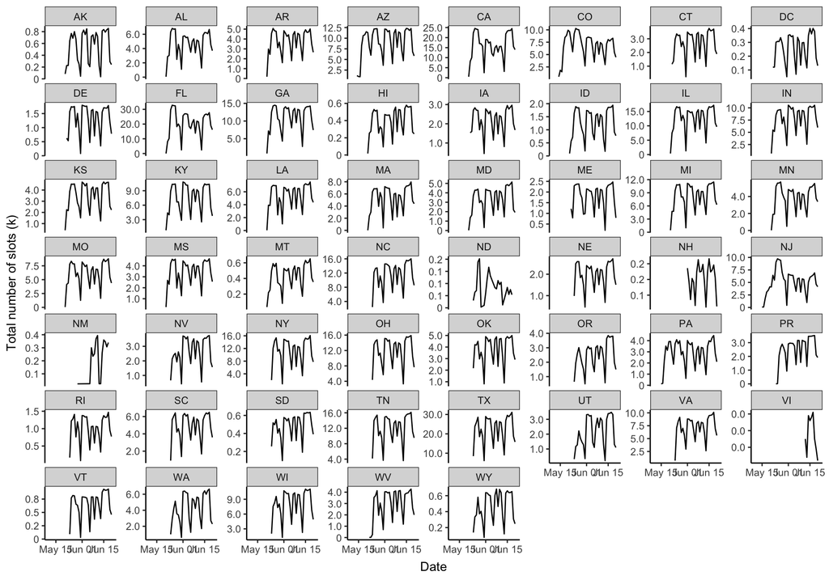

## Slot stats

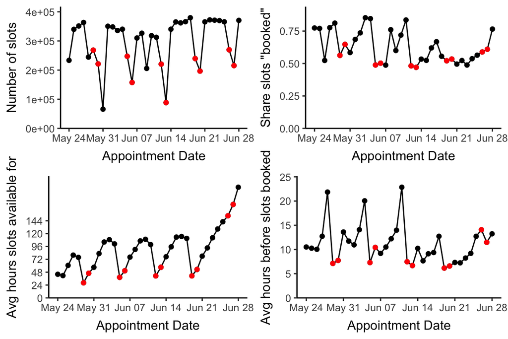

by state

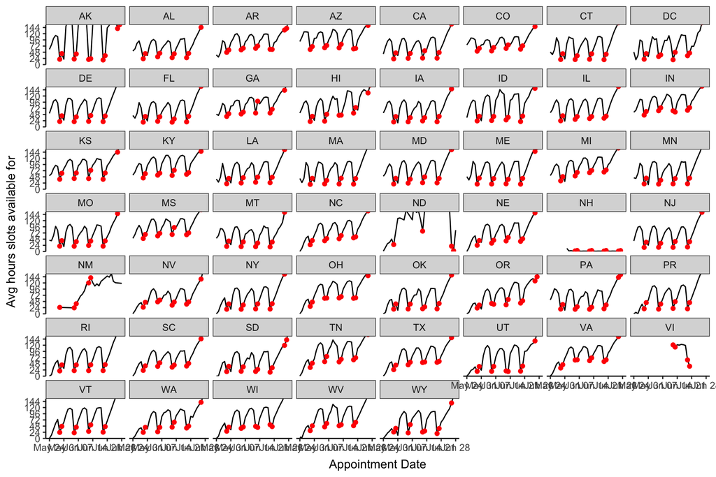

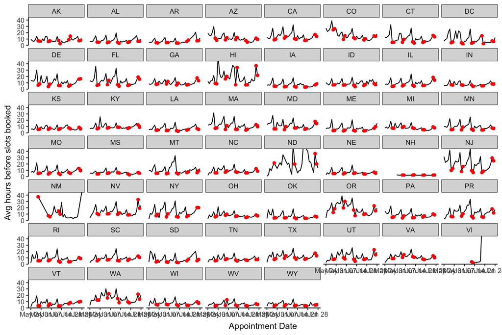

## Visualization of range of `checked_at` time

- sample 10 appointments per day (5 from walgreens and 5 other ones)
- Mondays are highlighted

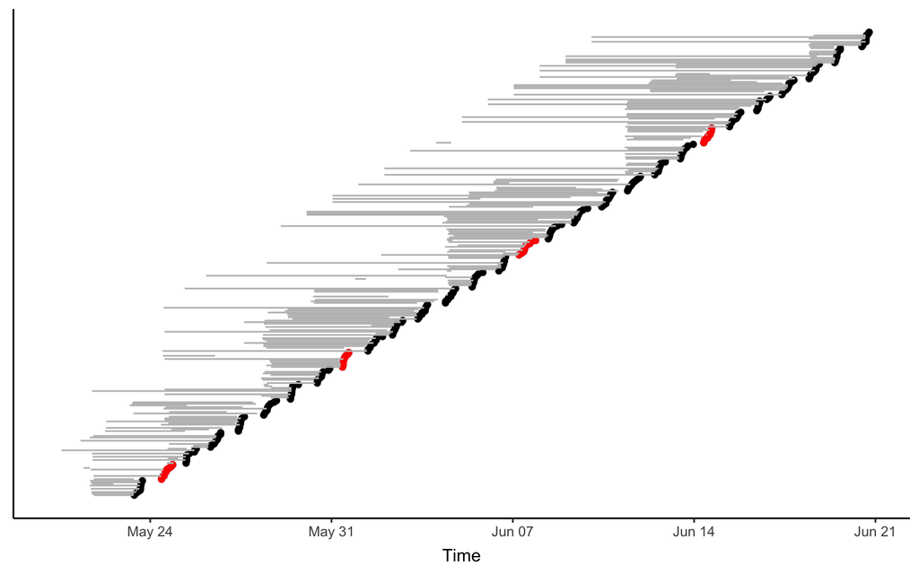

- Wallgreens is overrepresented and releases their appointments on Friday apparently.
- some appointments are availale after the slot time

## Availability by vulnerability (national, by zip)

We can compare appointment availability by the demographics of the area that the distribution location is in. The most granual level is the zip-code. Of course, people can travel to locations outside of their zip-code, and so a better analysis would, for every zip code, take an average of the nearby locations weighted by their distance.

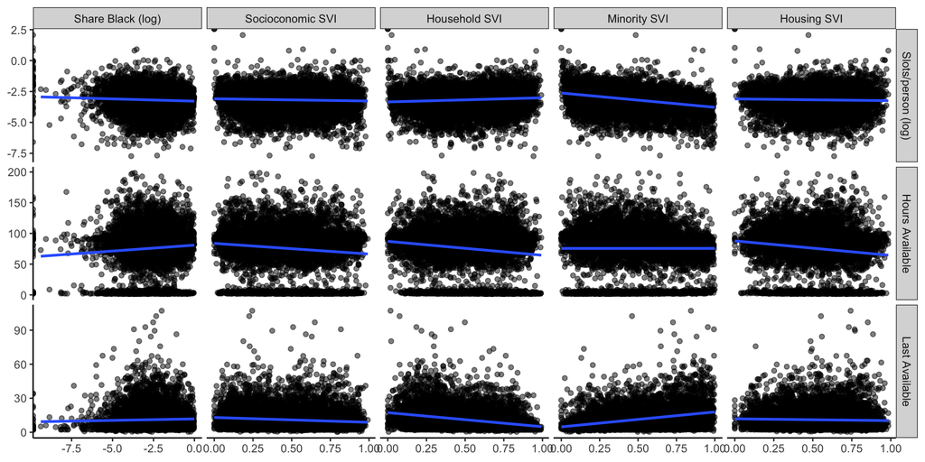

Note that for ‘last available’ (min lead time), less is better. For some indices, we see a **slight negative correlation between vulnerability and availability**.

*Note*: because we don’t have vaccination data on the zip-code level, we can’t (unlike below for counties) adjust slots/person by coverage, nor can we plot the SVI statistics against vaccination rates on a zip-code level.

We can combine these factors by running linear regressions for the outcome variable we’ve looked at so far (fixed effects for state not shown):

```
##
## ================================================================
##                                Dependent variable:
##                  -----------------------------------------------
##                  slots_per_person hours_available last_available
##                        (1)              (2)            (3)
## ----------------------------------------------------------------
## Population (log)    -0.078***        6.227***        1.053***
##                      (0.002)          (0.609)        (0.149)
## Share Black           0.008          24.065***      -3.122***
##                      (0.009)          (2.787)        (0.681)
## Socioeonomic SVI      0.005          -7.497**         -0.387
##                      (0.011)          (3.141)        (0.767)
## Household SVI       -0.053***       -17.336***      -7.040***
##                      (0.009)          (2.621)        (0.640)
## Minority SVI         0.049***         -2.175        12.065***
##                      (0.009)          (2.554)        (0.624)
## Housing SVI          -0.020**       -10.313***        -1.006
##                      (0.009)          (2.585)        (0.631)
## Intercept            0.860***        79.257***       -5.405**
##                      (0.036)         (10.559)        (2.578)
## ----------------------------------------------------------------
## Observations          8,030            8,030          8,030
## Adjusted R2           0.193            0.158          0.275
## ================================================================
## Note:                                *p<0.1; **p<0.05; ***p<0.01
```

## Does availability predict vaccinations? (national, by county)

- data is for 4 weeks: 2021-05-24 to 2021-06-20
- vaccination counts from covid act now

```
##
## =============================================================================
##                                          Dependent variable:
##                         -----------------------------------------------------
##                           n_vax/population              log(n_vax)
##                            (1)        (2)        (3)       (4)        (5)
## -----------------------------------------------------------------------------
## % hesitant (CDC)                     -0.011                         1.131**
##                                     (0.016)                         (0.450)
## Trump vote share                   -0.020***                       -0.375***
##                                     (0.002)                         (0.063)
## Prior vax rate                      0.00005                         0.004***
##                                    (0.00004)                        (0.001)
## Slots/Person (workday)   0.305***   0.249***             7.575***   5.625***
##                          (0.023)    (0.026)              (0.649)    (0.684)
## Slots/Person (weekend)   1.213***   1.411***            25.239***  34.575***
##                          (0.058)    (0.072)              (1.659)    (1.905)
## Slots/Person (evenings) -0.721***  -0.888***            -17.494*** -24.506***
##                          (0.073)    (0.085)              (2.046)    (2.246)
## Avg range (hrs)         -0.0001*** -0.0001***           -0.002***  -0.001***
##                         (0.00001)  (0.00001)             (0.0002)   (0.0002)
## Avg lead time (hrs)     0.0005***  0.0004***             0.009***   0.007***
##                         (0.00003)  (0.00004)             (0.001)    (0.001)
## Population (log)                              1.136***   1.079***   1.043***
##                                                (0.008)   (0.007)    (0.008)
## Intercept                0.019***   0.030***  -5.022*** -4.671***  -4.495***
##                          (0.003)    (0.008)    (0.147)   (0.113)    (0.256)
## -----------------------------------------------------------------------------
## Observations              1,389      1,016      1,389     1,389      1,016
## Adjusted R2               0.827      0.795      0.958     0.977      0.984
## =============================================================================
## Note:                                             *p<0.1; **p<0.05; ***p<0.01
```

**TODO**:

- add demographic variables?

### Week over week

Now, week over week (only two weeks since we don’t have vaccination numbers for this week until end of week):

```
##
## ===========================================================================================================
##                                                         Dependent variable:
##                          ----------------------------------------------------------------------------------
##                                       n_vax/population                            log(n_vax)
##                            (1)        (2)        (3)        (4)        (5)       (6)       (7)       (8)
## -----------------------------------------------------------------------------------------------------------
## Slots/Person                       0.086***              0.081***             10.109***           9.885***
##                                     (0.002)               (0.002)              (0.301)             (0.304)
## Average range (hrs)               -0.00002***           -0.00003***           -0.006***           -0.006***
##                                    (0.00000)             (0.00000)            (0.0002)            (0.0002)
## Average time ahead (hrs)           0.0001***             0.0001***            0.007***            0.007***
##                                    (0.00001)             (0.00001)             (0.001)             (0.001)
## % hesitant (CDC survey)                       -0.059***  -0.046***                      -5.183*** -2.919***
##                                                (0.004)    (0.004)                        (0.668)   (0.625)
## Prior vax rate                                0.003***   0.005***                       -0.663***  -0.034
##                                                (0.001)    (0.001)                        (0.162)   (0.154)
## Population (log)                                                    1.186***  1.227***  1.165***  1.208***
##                                                                      (0.009)   (0.008)   (0.010)   (0.009)
## Intercept                0.006***  0.005***   0.017***   0.013***   -7.457*** -7.512*** -5.851*** -6.667***
##                          (0.002)    (0.001)    (0.002)    (0.002)    (0.267)   (0.248)   (0.340)   (0.317)
## -----------------------------------------------------------------------------------------------------------
## Observations              11,215    11,215     10,960     10,960     11,215    11,215    10,960    10,960
## Adjusted R2               0.210      0.353      0.217      0.357      0.715     0.755     0.717     0.755
## ===========================================================================================================
## Note:                                                                           *p<0.1; **p<0.05; ***p<0.01
```